Jacob F. Brumley

# Background

The Joshua Tree is a desert adapted plant in the genus *Yucca* (Fig. 1). It’s name is considered to be from Mormon caravans that traversed the area before settling in northern Utah. The tale is that the trees reminded the Mormons of the story of Joshua, when he held his hands to God, guiding the Israelites victory in the Promised Land.

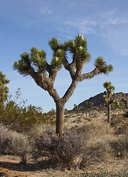

**Figure 1.** Joshua Tree, *Yucca brevifolia*.

The Joshua Tree is endemic to the southwestern United States, specifically within California, Utah, Nevada, and Arizona. (Fig. 2).

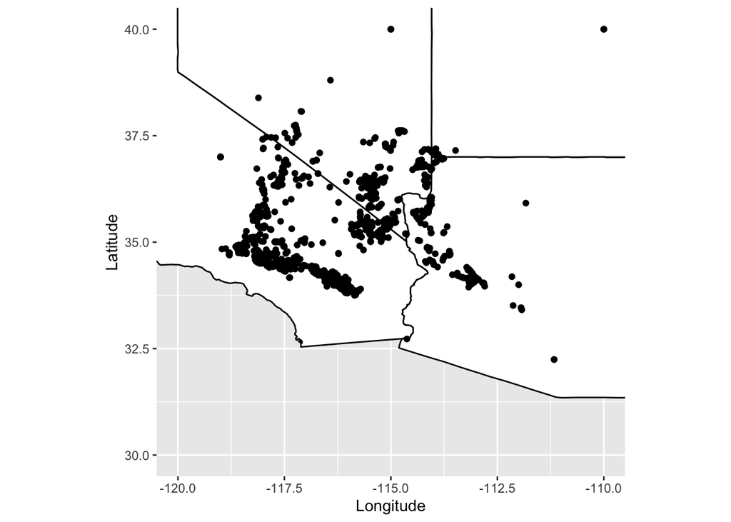

**Figure 2.** Location data for *Yucca brevifolia* in the southwestern United States.

Populations of the Joshua Tree mainly reside within the boundaries of the Mojave Desert at elevations of 1,300 to 5,900 feet above sea level. The species is considered a bioindicator of the health of the desert. Although considered a fast grower for a desert tree species, there is great threat to the existence of the extant populations of the Joshua Tree. Limited in its dispersal, conservationists are worried that global climate change will create an end to the species. Reports have been made concerning the spcies that predict the Joshua Tree will be eliminated from Joshua Tree National Park and restricted to 90% of its current range by the end of the 21st century.

# Species Distribution and Probability Model

With the species distribution and climate data, we created a model to predict places in the southwestern United States with a high probability of housing a Joshua Tree population (Fig. 3).

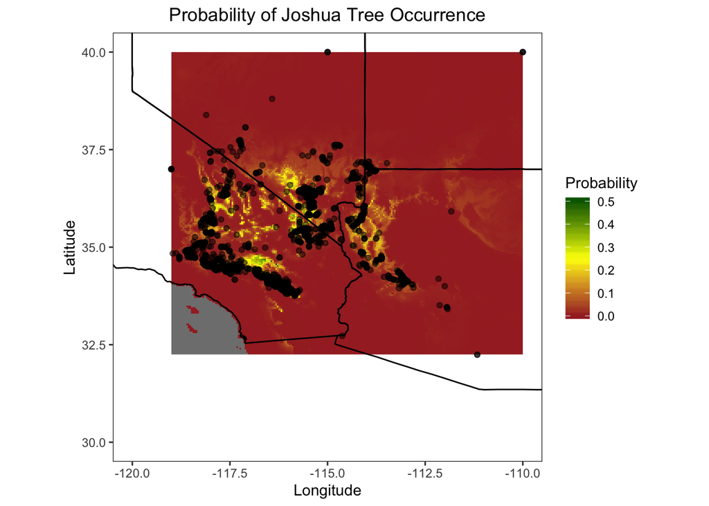

**Figure 3.** Model predicting probability of occurence of Joshua Tree populations.